# N1-doublet-detection

```python
from anndata import AnnData
import scrublet as scr
import pandas as pd
import scanpy as sc
import numpy as np
import scipy
import os

sc.settings.verbosity = 3  # verbosity: errors (0), warnings (1), info (2), hints (3)
sc.settings.figdir = './figures-N1-doublet-removal/'
sc.logging.print_versions()
```

```
scanpy==1.4.5.post2 anndata==0.6.22.post1 umap==0.3.10 numpy==1.18.1 scipy==1.4.1 pandas==0.25.3 scikit-learn==0.22.1 statsmodels==0.11.0rc2 python-igraph==0.7.1 louvain==0.6.1
```

```python
sc.settings.set_figure_params(dpi=80)  # low dpi (dots per inch) yields small inline figures
```

Benjamini-Hochberg and Bonferroni FDR helper functions.

```python
def bh(pvalues):
    """
    Computes the Benjamini-Hochberg FDR correction.

    Input:
        * pvals - vector of p-values to correct
    """
    pvalues = np.array(pvalues)
    n = int(pvalues.shape[0])
    new_pvalues = np.empty(n)
    values = [ (pvalue, i) for i, pvalue in enumerate(pvalues) ]
    values.sort()
    values.reverse()
    new_values = []
    for i, vals in enumerate(values):
        rank = n - i
        pvalue, index = vals
        new_values.append((n/rank) * pvalue)
    for i in range(0, int(n)-1):
        if new_values[i] < new_values[i+1]:
            new_values[i+1] = new_values[i]
    for i, vals in enumerate(values):
        pvalue, index = vals
        new_pvalues[index] = new_values[i]
    return new_pvalues

def bonf(pvalues):
    """
    Computes the Bonferroni FDR correction.

    Input:
        * pvals - vector of p-values to correct
    """
    new_pvalues = np.array(pvalues) * len(pvalues)
    new_pvalues[new_pvalues>1] = 1
    return new_pvalues
```

Import the per-sample metadata, and download all the expression data from an internal iRODS system. The mappings are done by starsolo, which outputs a cellranger 2 mimicking three-file folder.

```python
meta = pd.read_csv('meta.csv',index_col=0)
plotmeta = list(meta.columns)
plotmeta.append('sample')

if not os.path.exists('rawdata'):
    os.makedirs('rawdata')
    for sample in meta.index:
        os.system('iget -Kr /archive/HCA/10X/'+sample+'/starsolo/counts/filtered rawdata/'+sample)
        os.system('iget -K /archive/HCA/10X/'+sample+'/starsolo/counts/Summary.csv rawdata/'+sample)
```

Two-step doublet score processing, mirroring the approach from Popescu *et al.* https://www.nature.com/articles/s41586-019-1652-y which was closely based on Pijuan-Sala *et al.* https://www.nature.com/articles/s41586-019-0933-9

The first step starts with some sort of doublet score, e.g. Scrublet, and ends up with a per-cell p-value (with significant values marking doublets). For each sample individually:

- run Scrublet to obtain each cell's score
- overcluster the manifold - run a basic Scanpy pipeline up to clustering, then additionally cluster each cluster separately
- compute per-cluster Scrublet scores as the median of the observed values, and use those going forward
- identify p-values:
  - compute normal distribution parameters: centered at the median of the scores, with a MAD-derived standard deviation
  - the score distribution is zero-truncated, so as per the paper I only use above-median values to compute the MAD
  - I then deviate from the paper a bit, at least the exact wording captured within it, and multiply the MAD by 1.4826 to obtain a literature-derived normal distribution standard deviation estimate
- FDR-correct the p-values via Benjamini-Hochberg
- write out all this doublet info into CSVs for later use

The second step is performed later, in a multi-sample space.

```python
#there's loads of clustering going on, so set verbosity low unless you enjoy walls of text
sc.settings.verbosity = 0  # verbosity: errors (0), warnings (1), info (2), hints (3)

scorenames = ['scrublet_score','scrublet_cluster_score','zscore','bh_pval','bonf_pval']
if not os.path.exists('scrublet-scores'):
    os.makedirs('scrublet-scores')
    #loop over the subfolders of the rawdata folder
    for sample in meta.index:
        #import data
        adata_sample = sc.read_10x_mtx('rawdata/'+sample, cache=True)
        adata_sample.var_names_make_unique()
        #rename cells to SAMPLE_BARCODE
        adata_sample.obs_names = [sample+'_'+i for i in adata_sample.obs_names]
        #do some early filtering to retain meaningful cells for doublet inspection
        sc.pp.filter_cells(adata_sample, min_genes=500)
        sc.pp.filter_genes(adata_sample, min_cells=3)
        #convert to lower to be species agnostic: human mito start with MT-, mouse with mt-
        mito_genes = [name for name in adata_sample.var_names if name.lower().startswith('mt-')]
        # for each cell compute fraction of counts in mito genes vs. all genes
        # the `.A1` is only necessary as X is sparse (to transform to a dense array after summing)
        adata_sample.obs['percent_mito'] = np.sum(
            adata_sample[:, mito_genes].X, axis=1).A1 / np.sum(adata_sample.X, axis=1).A1
        adata_sample = adata_sample[adata_sample.obs['percent_mito'] < 0.2, :]

        #set up and run Scrublet, seeding for replicability
        np.random.seed(0)
        scrub = scr.Scrublet(adata_sample.X)
        doublet_scores, predicted_doublets = scrub.scrub_doublets(verbose=False)
        adata_sample.obs['scrublet_score'] = doublet_scores

        #overcluster prep. run turbo basic scanpy pipeline
        sc.pp.normalize_per_cell(adata_sample, counts_per_cell_after=1e4)
        sc.pp.log1p(adata_sample)
        sc.pp.highly_variable_genes(adata_sample, min_mean=0.0125, max_mean=3, min_disp=0.5)
        adata_sample = adata_sample[:, adata_sample.var['highly_variable']]
        sc.pp.scale(adata_sample, max_value=10)
        sc.tl.pca(adata_sample, svd_solver='arpack')
        sc.pp.neighbors(adata_sample)
        #overclustering proper - do basic clustering first, then cluster each cluster
        sc.tl.leiden(adata_sample)
        adata_sample.obs['leiden'] = [str(i) for i in adata_sample.obs['leiden']]
        for clus in np.unique(adata_sample.obs['leiden']):
            adata_sub = adata_sample[adata_sample.obs['leiden']==clus].copy()
            sc.tl.leiden(adata_sub)
            adata_sub.obs['leiden'] = [clus+','+i for i in adata_sub.obs['leiden']]
            adata_sample.obs.loc[adata_sub.obs_names,'leiden'] = adata_sub.obs['leiden']

        #compute the cluster scores - the median of Scrublet scores per overclustered cluster
        for clus in np.unique(adata_sample.obs['leiden']):
            adata_sample.obs.loc[adata_sample.obs['leiden']==clus, 'scrublet_cluster_score'] = \
                np.median(adata_sample.obs.loc[adata_sample.obs['leiden']==clus, 'scrublet_score'])
        #now compute doublet p-values. figure out the median and mad (from above-median values) for the distribution
        med = np.median(adata_sample.obs['scrublet_cluster_score'])
        mask = adata_sample.obs['scrublet_cluster_score']>med
        mad = np.median(adata_sample.obs['scrublet_cluster_score'][mask]-med)
        #let's do a one-sided test. the Bertie write-up does not address this but it makes sense
        zscores = (adata_sample.obs['scrublet_cluster_score'].values - med) / (1.4826 * mad)
        adata_sample.obs['zscore'] = zscores
        pvals = 1-scipy.stats.norm.cdf(zscores)
        adata_sample.obs['bh_pval'] = bh(pvals)
        adata_sample.obs['bonf_pval'] = bonf(pvals)

        #create results data frame for single sample and copy stuff over from the adata object
        scrublet_sample = pd.DataFrame(0, index=adata_sample.obs_names, columns=scorenames)
        for score in scorenames:
            scrublet_sample[score] = adata_sample.obs[score]
        #write out complete sample scores
        scrublet_sample.to_csv('scrublet-scores/'+sample+'.csv')
```

With the first step out of the way, normal levels of verbosity can resume. Create a joint object with all the samples.

```python
sc.settings.verbosity = 3  # verbosity: errors (0), warnings (1), info (2), hints (3)

holder = []
#loop over the subfolders of the rawdata folder
for sample in meta.index:
    #import data
    holder.append(sc.read_10x_mtx('rawdata/'+sample, cache=True))
    holder[-1].var_names_make_unique()
    #rename cells to SAMPLE_BARCODE
    holder[-1].obs_names = [sample+'_'+i for i in holder[-1].obs_names]
    #add in metadata
    holder[-1].obs['sample'] = sample
    for val in meta.columns:
        holder[-1].obs[val] = meta[val][sample]

adata = holder[0].concatenate(holder[1:], index_unique=None)
```

```
... reading from cache file cache/rawdata-MRC_Endo8625698-matrix.h5ad
... reading from cache file cache/rawdata-MRC_Endo8625699-matrix.h5ad
... reading from cache file cache/rawdata-MRC_Endo8712024-matrix.h5ad
... reading from cache file cache/rawdata-MRC_Endo8712032-matrix.h5ad
... reading from cache file cache/rawdata-MRC_Endo8715415-matrix.h5ad
... reading from cache file cache/rawdata-MRC_Endo8715416-matrix.h5ad
```

Perform preliminary filtering - 500 gene minimum, 20% mitochondrial maximum. Store post-gene-minimum raw data in `.raw`. `log(CPM/100 + 1)` the data and keep that in `.X`.

```python
sc.pp.filter_cells(adata, min_genes=500)
adata.raw = adata.copy()
sc.pp.filter_genes(adata, min_cells=3)
#convert to lower to be species agnostic: human mito start with MT-, mouse with mt-
mito_genes = [name for name in adata.var_names if name.lower().startswith('mt-')]
# for each cell compute fraction of counts in mito genes vs. all genes
# the `.A1` is only necessary as X is sparse (to transform to a dense array after summing)
adata.obs['percent_mito'] = np.sum(
    adata[:, mito_genes].X, axis=1).A1 / np.sum(adata.X, axis=1).A1
adata = adata[adata.obs['percent_mito'] < 0.2, :]
sc.pp.normalize_per_cell(adata, counts_per_cell_after=1e4)
sc.pp.log1p(adata)
```

```
filtered out 3712 cells that have less than 500 genes expressed
filtered out 8910 genes that are detected in less than 3 cells
normalizing by total count per cell
```

```
Trying to set attribute `.obs` of view, making a copy.
```

```
    finished (0:00:02): normalized adata.X and added    'n_counts', counts per cell before normalization (adata.obs)
```

Identify cell cycling genes by performing the standard Scanpy pipeline in gene space (i.e. transposing the object).

```
extracting highly variable genes
    finished (0:00:02)
--> added
    'highly_variable', boolean vector (adata.var)
    'means', float vector (adata.var)
    'dispersions', float vector (adata.var)
    'dispersions_norm', float vector (adata.var)
computing PCA with n_comps = 50
    finished (0:00:01)
WARNING: saving figure to file figures-N1-doublet-removal/pca_variance_ratio_ccg_identification.pdf
```

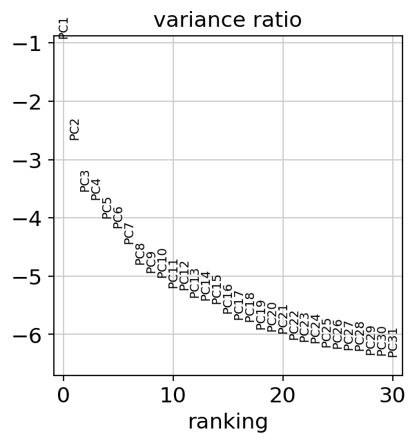

```python
bdata = adata.copy()
sc.pp.highly_variable_genes(bdata, min_mean=0.0125, max_mean=3, min_disp=0.5)
bdata = bdata[:, bdata.var['highly_variable']]
bdata = bdata.copy().T
sc.pp.scale(bdata, max_value=10)
sc.tl.pca(bdata, svd_solver='arpack')
sc.pl.pca_variance_ratio(bdata, log=True, save='_ccg_identification.pdf')
```

Compute and plot the clustering of the genes in UMAP space, along with known cycling genes.

```
computing neighbors
    using 'X_pca' with n_pcs = 20
    finished: added to `.uns['neighbors']`
    'distances', distances for each pair of neighbors
    'connectivities', weighted adjacency matrix (0:00:02)
computing UMAP
    finished: added
    'X_umap', UMAP coordinates (adata.obsm) (0:00:06)
running Leiden clustering
    finished: found 9 clusters and added
    'leiden', the cluster labels (adata.obs, categorical) (0:00:00)
```

```
... storing 'clinical' as categorical
... storing 'day' as categorical
... storing 'individual' as categorical
... storing 'phase' as categorical
... storing 'sample' as categorical
... storing 'treatment' as categorical
... storing 'type' as categorical
```

```
WARNING: saving figure to file figures-N1-doublet-removal/umap_ccg_identification.pdf
```

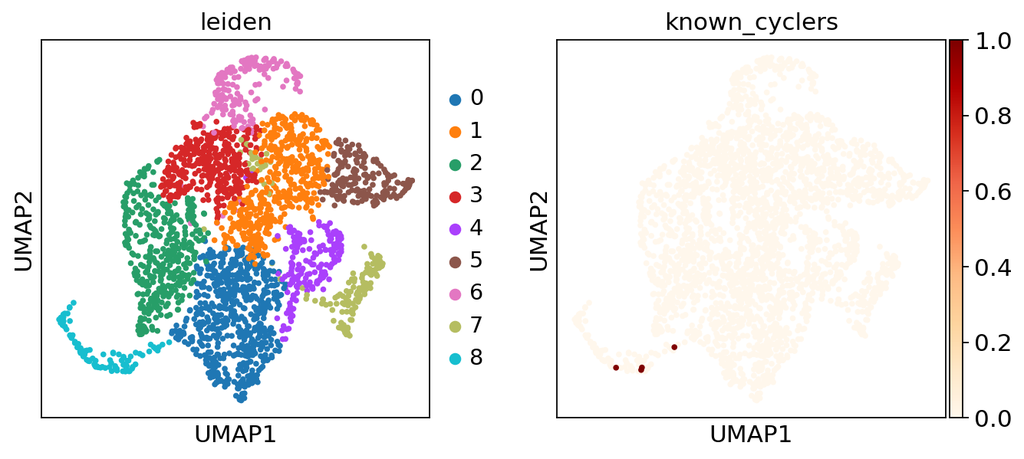

```
CDK1     8
MKI67    8
CCNB2    8
PCNA     8
Name: leiden, dtype: category
Categories (9, object): [0, 1, 2, 3, ..., 5, 6, 7, 8]
```

```python
num_pcs = 20

sc.pp.neighbors(bdata,n_pcs=num_pcs)
sc.tl.umap(bdata)
sc.tl.leiden(bdata, resolution=0.4)
bdata.obs['known_cyclers'] = [i in ['CDK1','MKI67','CCNB2','PCNA'] for i in bdata.obs_names]
sc.pl.umap(bdata,color=['leiden','known_cyclers'],color_map='OrRd',save='_ccg_identification.pdf')

print(bdata.obs.loc[['CDK1','MKI67','CCNB2','PCNA'],'leiden'])
```

Flag the cyclers and continue with the Scanpy pipeline in a helper object, so that dimensionality can be unaffected in the original one.

```
extracting highly variable genes
    finished (0:00:02)
--> added
    'highly_variable', boolean vector (adata.var)
    'means', float vector (adata.var)
    'dispersions', float vector (adata.var)
    'dispersions_norm', float vector (adata.var)
```

```
Trying to set attribute `.var` of view, making a copy.
```

```
computing PCA with n_comps = 50
    on highly variable genes
    finished (0:00:01)
WARNING: saving figure to file figures-N1-doublet-removal/pca_variance_ratio.pdf
```

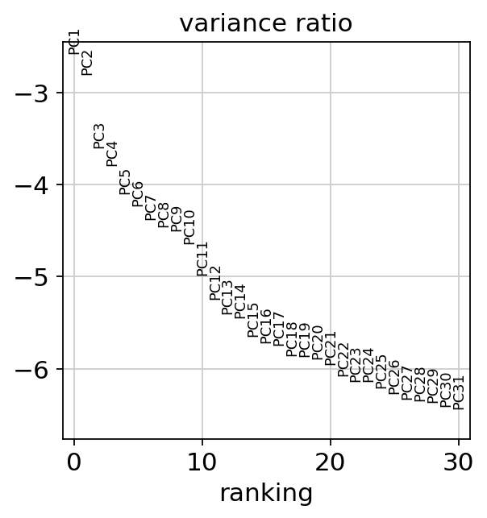

```python
adata.var['is_ccg'] = [i in bdata.obs[bdata.obs['leiden']=='8'].index for i in adata.var_names]
#compute HVG and PCA on separate helper object and port the results back to the original one
bdata = adata[:, ~adata.var['is_ccg']]
sc.pp.highly_variable_genes(bdata, min_mean=0.0125, max_mean=3, min_disp=0.5)
for col in ['highly_variable','means', 'dispersions', 'dispersions_norm']:
    adata.var[col] = bdata.var[col]
#fill NaNs with False so that subsetting to HVGs is possible
adata.var['highly_variable'].fillna(value=False, inplace=True)
bdata = bdata[:, bdata.var['highly_variable']]
sc.pp.scale(bdata, max_value=10)
sc.tl.pca(bdata, svd_solver='arpack', n_comps=50)
adata.obsm['X_pca'] = bdata.obsm['X_pca'].copy()
adata.uns['pca'] = bdata.uns['pca'].copy()
adata.varm['PCs'] = np.zeros(shape=(adata.n_vars, 50))
adata.varm['PCs'][adata.var['highly_variable']] = bdata.varm['PCs']
sc.pl.pca_variance_ratio(adata, log=True, save='.pdf')
```

Handle cross-individual technical differences with Harmony. That's in R, so prepare data for porting over, then run Harmony in R.

```python
num_pcs = 20

pca = adata.obsm['X_pca'][:, :num_pcs]
batch = adata.obs['individual']
```

```python
%load_ext rpy2.ipython
```

```python
%%R -i pca -i batch -o hem

library(harmony)
library(magrittr)

#this gets "90% of the way" to determinism. better than nothing.
set.seed(1)

hem = HarmonyMatrix(pca, batch, theta=4, verbose=FALSE, do_pca=FALSE)
hem = data.frame(hem)
```

```
R[write to console]: Loading required package: Rcpp
```

Compute a UMAP (and clustering) based on the Harmony embedding, plot stuff on the UMAP.

```
computing neighbors
```

[output not shown]

```
    finished: added to `.uns['neighbors']`
    'distances', distances for each pair of neighbors
    'connectivities', weighted adjacency matrix (0:00:07)
running Leiden clustering
    finished: found 135 clusters and added
    'leiden', the cluster labels (adata.obs, categorical) (0:00:07)
computing UMAP
    finished: added
    'X_umap', UMAP coordinates (adata.obsm) (0:00:12)
```

```
... storing 'clinical' as categorical
... storing 'day' as categorical
... storing 'individual' as categorical
... storing 'phase' as categorical
... storing 'sample' as categorical
... storing 'treatment' as categorical
... storing 'type' as categorical
```

```
WARNING: saving figure to file figures-N1-doublet-removal/umap.pdf
```

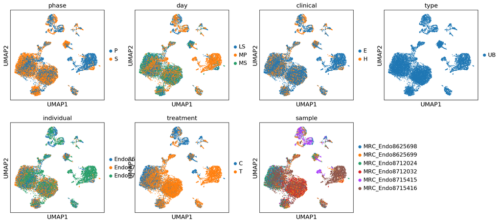

```python
adata.obsm['X_harmony'] = hem.values
sc.pp.neighbors(adata, use_rep='X_harmony')
sc.tl.leiden(adata, resolution = 10)
sc.tl.umap(adata)

sc.pl.umap(adata, color=plotmeta, save='.pdf')
```

Import the prior scrublet scores and add them into the object.

Execute second step of Popescu *et al.*, computing the frequency of doublets in the joint manifold clusters and processing the distribution like the scores in the first step. Call doublets using Bonferroni corrected p-values, with a 0.01 stringency threshold.

```
WARNING: saving figure to file figures-N1-doublet-removal/umap_doublets.pdf
```

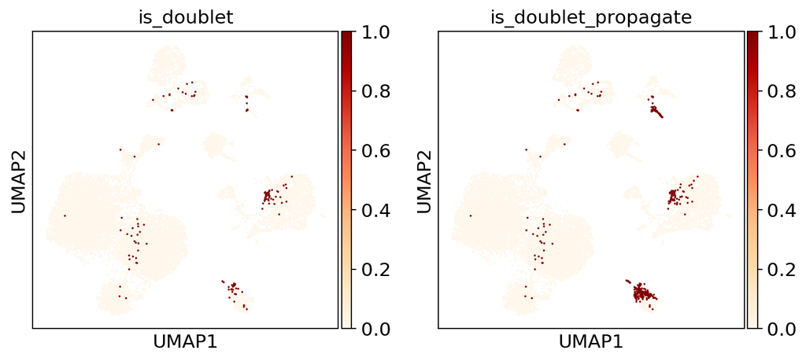

```python
cluster_key = 'leiden'

scrdf = []
for sample in meta.index:
    scrdf.append(pd.read_csv('scrublet-scores/'+sample+'.csv', header=0, index_col=0))
scrdf = pd.concat(scrdf)
for score in scorenames:
    adata.obs[score] = scrdf[score]

adata.obs['is_doublet'] = adata.obs['bonf_pval'] < 0.01
doublet_counts = adata.obs.loc[:,['is_doublet', cluster_key]].groupby(cluster_key).mean()

#the actual computation happens here
med = np.median(doublet_counts)
mask = doublet_counts.values>med
mad = np.median(doublet_counts.values[mask]-med)
pvals = 1-scipy.stats.norm.cdf(doublet_counts, loc=med, scale=1.4826*mad)
pvals_adj = bonf(pvals)
doublet_populations = list(doublet_counts.index[pvals_adj.flatten()<0.01])

#flag the entirety of the doublet populations as doublets
adata.obs['is_doublet_propagate'] = adata.obs['is_doublet'].copy()
adata.obs.loc[[i in doublet_populations for i in adata.obs[cluster_key]],'is_doublet_propagate'] = True

sc.pl.umap(adata, color=['is_doublet','is_doublet_propagate'], color_map='OrRd', save='_doublets.pdf')
```

Write out the object.

```python
adata.write('endometrium-N1-doublet-removal.h5ad')
```